# Homework10 For Loops and Randomization

Daniel Penados-Richter

2024-04-03

1. Using a for loop, write a function to calculate the number of zeroes in a numeric vector. Before entering the loop, set up a counter variable counter <- 0. Inside the loop, add 1 to counter each time you have a zero in the vector. Finally, use return(counter) for the output.
2. Use subsetting instead of a loop to rewrite the function as a single line of code.

```r
#Vector
x <- c(0,1,2,3,0,3,7,4,0,4,0,0,0,4)
#for loop to count 0's
counter <- 0
for (i in x) {
  if (i == 0) {
    counter <- counter + 1
  }
}

print(counter)
```

```
## [1] 6
```

```r
#another for, simpler using subsetting.

print(sum(x == 0))
```

```
## [1] 6
```

3. Write a function that takes as input two integers representing the number of rows and columns in a matrix. The output is a matrix of these dimensions in which each element is the product of the row number x the column number.

```r
rows <- 3
cols <- 4
matrix1 <- matrix_function(rows, cols)
print(matrix1)
```

```
##      [,1] [,2] [,3] [,4]
## [1,]    1    2    3    4
## [2,]    2    4    6    8
## [3,]    3    6    9   12
```

4a. Simulate a dataset with 3 groups of data, each group drawn from a distribution with a different mean. The final data frame should have 1 column for group and 1 column for the response variable.

4b. Write a custom function that 1) reshuffles the response variable, and 2) calculates the mean of each group in the reshuffled data. Store the means in a vector of length 3.

4c. Use a for loop to repeat the function in b 100 times. Store the results in a data frame that has 1 column indicating the replicate number and 1 column for each new group mean, for a total of 4 columns.

4d. Use qplot() to create a histogram of the means for each reshuffled group. Or, if you want a challenge, use ggplot() to overlay all 3 histograms in the same figure. How do the distributions of reshuffled means compare to the original means?

```r
#Using my function generate_random_data to create a group 3 with different means, N's, and CV's. Dataframe in a long vertion.
my_data<-generate_random_data(n_groups = 3)
head(my_data)
```

```
##     Group    Value
## 1 Group_1 23.15628
## 2 Group_1 24.91941
## 3 Group_1 21.03801
## 4 Group_1 22.75493
## 5 Group_1 16.43838
## 6 Group_1 26.96913
```

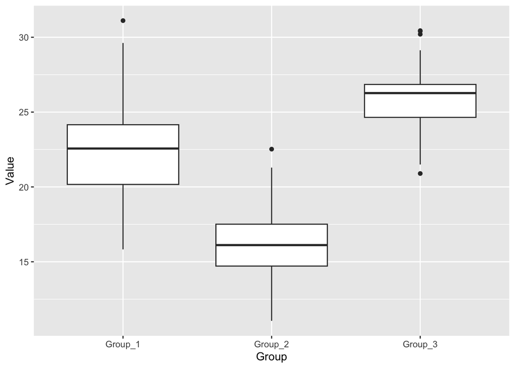

```r
w<-ggplot(my_data, aes(x = Group, y = Value)) +
  geom_boxplot() +
  labs(x = "Group", y = "Value")
print(w)
```

```r
#shuffle my data and print the mean of each group in a vector.

shuffle_mean<-shuffle_response(my_data)
print(shuffle_mean)
```

```
## [1] 20.73911 20.56692 21.23878
```

```r
#Repeat this 100 times, and store in a new data frame

# Number of iterations
N <- 100

#New df, with a first column = to n_interations, second a 3 row matrix filled with NA values for every interation.
my_results <- data.frame(iteration = 1:N, matrix(NA, nrow = N, ncol = 3))
#Change column names from column 2 to 4.
colnames(my_results)[-1] <- c("Group_1", "Group_2", "Group_3")
head(my_results)
```

```
##   iteration Group_1 Group_2 Group_3
## 1         1      NA      NA      NA
## 2         2      NA      NA      NA
## 3         3      NA      NA      NA
## 4         4      NA      NA      NA
## 5         5      NA      NA      NA
## 6         6      NA      NA      NA
```

```r
# Repeat the function 100 times and store the results
for (i in 1:N) { # repeat funtion in i N number of times.
  values <- shuffle_response(my_data)
  my_results[i, -1] <- values #store vector results in column 2 to 4.
}
glimpse(my_results)
```

```
## Rows: 100
## Columns: 4
## $ iteration <int> 1, 2, 3, 4, 5, 6, 7, 8, 9, 10, 11, 12, 13, 14, 15, 16, 17, 1…
## $ Group_1   <dbl> 20.95041, 21.93417, 20.83981, 20.74572, 20.36495, 20.83377, …
## $ Group_2   <dbl> 20.80930, 20.35667, 20.62473, 20.27474, 21.07885, 21.12405, …
## $ Group_3   <dbl> 20.61232, 20.12816, 21.02899, 21.68035, 20.90019, 20.26806, …
```

```r
#create a boxplot
new_resuls <- my_results[, c("Group_1", "Group_2", "Group_3")]

#convert to long version for ggplot.
long_results <- pivot_longer(new_resuls, cols = starts_with("Group"), names_to = "Group", values_to = "Value")
head(long_results)
```

```
## # A tibble: 6 × 2
##   Group   Value
##   <chr>   <dbl>
## 1 Group_1  21.0
## 2 Group_2  20.8
## 3 Group_3  20.6
## 4 Group_1  21.9
## 5 Group_2  20.4
## 6 Group_3  20.1
```

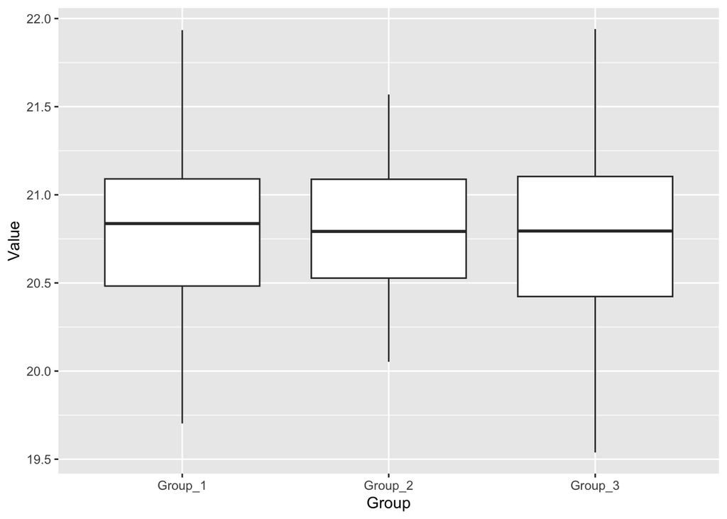

```r
x<-ggplot(long_results, aes(x = Group, y = Value)) +
  geom_boxplot() +
  labs(x = "Group", y = "Value")
print(x)
```

Comparing the results of the original data set `my_data`, and the shuffle one. Since the first random generate data set, `my_data` will shown different mean values for each group. When we shuffle the values, it is possible that the means become similar. This becouse shuffle function, mixes tha `Values` independently from each group. Creating a more homgeneaus mean among groups.